# Exploratory Analysis of Heart Disease and Oesophageal Cancer Data

Software for Data Analysis, Lab 01: Final deliverable (PEC1)

Marcos Cunchillos Just

2026-10-23

# Overview

This report applies the core R workflow of the module (importing and exporting data, data wrangling, descriptive statistics and graphics) to two clinical datasets:

| Dataset | Source | Design | Question |
| --- | --- | --- | --- |
| `heart.csv` (Statlog Heart Disease) | UCI Machine Learning Repository | 270 patients, 14 clinical variables | Which clinical features differ between patients with and without heart disease? |
| `esoph` | `datasets` (R) | Aggregated case-control study, Ille-et-Vilaine (France) | How are alcohol and tobacco intake related to oesophageal cancer? |

**Reproducibility:** place `heart.csv` in a `data/` folder next to this file and knit. The `esoph` export is written to `output/`. Both folders are excluded from version control.

```r
library(readr)
library(dplyr)
library(ggplot2)

# Consistent, colour-blind-friendly palette for disease status
status_colours <- c(Healthy = "#009E73", Disease = "#D55E00")
```

# Part 1. Data import, export and management

## 1.1 Importing the heart disease data

```r
heart_data <- read_csv("data/heart.csv")

head(heart_data)
```

| age | sex | cp | trestbps | chol | fbs | restecg | thalach | exang | oldpeak | slope | ca | thal | target |
| --- | --- | --- | --- | --- | --- | --- | --- | --- | --- | --- | --- | --- | --- |
| 70 | 1 | 3 | 130 | 322 | 0 | 2 | 109 | 0 | 2.4 | 1 | 3 | 1 | 1 |
| 67 | 0 | 2 | 115 | 564 | 0 | 2 | 160 | 0 | 1.6 | 1 | 0 | 3 | 0 |
| 57 | 1 | 1 | 124 | 261 | 0 | 0 | 141 | 0 | 0.3 | 0 | 0 | 3 | 1 |
| 64 | 1 | 3 | 128 | 263 | 0 | 0 | 105 | 1 | 0.2 | 1 | 1 | 3 | 0 |
| 74 | 0 | 1 | 120 | 269 | 0 | 2 | 121 | 1 | 0.2 | 0 | 1 | 1 | 0 |
| 65 | 1 | 3 | 120 | 177 | 0 | 0 | 140 | 0 | 0.4 | 0 | 0 | 3 | 0 |

```r
tail(heart_data)
```

| age | sex | cp | trestbps | chol | fbs | restecg | thalach | exang | oldpeak | slope | ca | thal | target |
| --- | --- | --- | --- | --- | --- | --- | --- | --- | --- | --- | --- | --- | --- |
| 48 | 1 | 1 | 110 | 229 | 0 | 0 | 168 | 0 | 1.0 | 2 | 0 | 3 | 1 |
| 52 | 1 | 2 | 172 | 199 | 1 | 0 | 162 | 0 | 0.5 | 0 | 0 | 3 | 0 |
| 44 | 1 | 1 | 120 | 263 | 0 | 0 | 173 | 0 | 0.0 | 0 | 0 | 3 | 0 |
| 56 | 0 | 1 | 140 | 294 | 0 | 2 | 153 | 0 | 1.3 | 1 | 0 | 1 | 0 |
| 57 | 1 | 3 | 140 | 192 | 0 | 0 | 148 | 0 | 0.4 | 1 | 0 | 2 | 0 |
| 67 | 1 | 3 | 160 | 286 | 0 | 2 | 108 | 1 | 1.5 | 1 | 3 | 1 | 1 |

## 1.2 Dataset description

```r
str(heart_data)
```

```
## spc_tbl_ [270 × 14] (S3: spec_tbl_df/tbl_df/tbl/data.frame)
##  $ age     : num [1:270] 70 67 57 64 74 65 56 59 60 63 ...
##  $ sex     : num [1:270] 1 0 1 1 0 1 1 1 1 0 ...
##  $ cp      : num [1:270] 3 2 1 3 1 3 2 3 3 3 ...
##  $ trestbps: num [1:270] 130 115 124 128 120 120 130 110 140 150 ...
##  $ chol    : num [1:270] 322 564 261 263 269 177 256 239 293 407 ...
##  $ fbs     : num [1:270] 0 0 0 0 0 0 1 0 0 0 ...
##  $ restecg : num [1:270] 2 2 0 0 2 0 2 2 2 2 ...
##  $ thalach : num [1:270] 109 160 141 105 121 140 142 142 170 154 ...
##  $ exang   : num [1:270] 0 0 0 1 1 0 1 1 0 0 ...
##  $ oldpeak : num [1:270] 2.4 1.6 0.3 0.2 0.2 0.4 0.6 1.2 1.2 4 ...
##  $ slope   : num [1:270] 1 1 0 1 0 0 1 1 1 1 ...
##  $ ca      : num [1:270] 3 0 0 1 1 0 1 1 2 3 ...
##  $ thal    : num [1:270] 1 3 3 3 1 3 2 3 3 3 ...
##  $ target  : num [1:270] 1 0 1 0 0 0 1 1 1 1 ...
##  - attr(*, "spec")=
##   .. cols(
##   ..   age = col_double(),
##   ..   sex = col_double(),
##   ..   cp = col_double(),
##   ..   trestbps = col_double(),
##   ..   chol = col_double(),
##   ..   fbs = col_double(),
##   ..   restecg = col_double(),
##   ..   thalach = col_double(),
##   ..   exang = col_double(),
##   ..   oldpeak = col_double(),
##   ..   slope = col_double(),
##   ..   ca = col_double(),
##   ..   thal = col_double(),
##   ..   target = col_double()
##   .. )
##  - attr(*, "problems")=<pointer: 0x000001f9ba2fe9f0>
```

```r
dim(heart_data)
```

```
## [1] 270  14
```

```r
# Missing-value screening: overall and per variable
any(is.na(heart_data))
```

```
## [1] FALSE
```

```r
colSums(is.na(heart_data))
```

```
##      age      sex       cp trestbps     chol      fbs  restecg  thalach
##        0        0        0        0        0        0        0        0
##    exang  oldpeak    slope       ca     thal   target
##        0        0        0        0        0        0
```

The dataset contains **270 patients** (rows) and **14 variables** (columns), with **no missing values**. All variables are stored as numeric, but several are categorical variables encoded as integers, which matters for choosing the right summary and plot:

| Variable | Meaning | True nature | Suitable exploration |
| --- | --- | --- | --- |
| `age` | Age (years) | Quantitative | Histogram, boxplot |
| `sex` | Sex (1 = male, 0 = female) | Categorical | Bar plot, contingency table |
| `cp` | Chest pain type (0-3) | Categorical | Bar plot, contingency table |
| `trestbps` | Resting blood pressure (mm Hg) | Quantitative | Histogram, boxplot |
| `chol` | Serum cholesterol (mg/dl) | Quantitative | Histogram, Q-Q plot |
| `fbs` | Fasting blood sugar > 120 mg/dl (1 = yes) | Categorical | Contingency table |
| `restecg` | Resting ECG result (0-2) | Categorical | Contingency table, heatmap |
| `thalach` | Maximum heart rate achieved | Quantitative | Boxplot by group |
| `exang` | Exercise-induced angina (1 = yes) | Categorical | Contingency table |
| `oldpeak` | ST depression induced by exercise | Quantitative | Histogram, correlation |
| `slope` | Slope of the peak-exercise ST segment (0-2) | Categorical | Contingency table |
| `ca` | Major vessels coloured by fluoroscopy (0-3) | Categorical | Bar plot |
| `thal` | Thallium stress test result (1-3) | Categorical | Bar plot |
| `target` | Heart disease (1 = present, 0 = absent) | Categorical | Grouping variable |

## 1.3 Complete-case analysis and selection bias

Dropping every patient with a missing value (complete-case analysis) implicitly assumes that data are missing completely at random, which is rarely true in clinical records. Patients who are most severely ill often cannot tolerate or finish all examinations, so excluding them underestimates disease severity. Patients who drop out of follow-up because of side effects also disappear, which inflates the apparent safety and efficacy of a treatment. Fragmented records are also more common in socioeconomically vulnerable groups with poorer access to healthcare, so these populations become under-represented. On top of this selection bias, discarding rows reduces the sample size, which lowers statistical power and increases the risk of missing real effects. The resulting estimates lose external validity, and safer strategies (examining the missingness mechanism, multiple imputation, or model-based approaches) are preferable.

## 2.1 The `esoph` dataset

```r
data("esoph")
head(esoph)
```

|  | agegp | alcgp | tobgp | ncases | ncontrols |
| --- | --- | --- | --- | --- | --- |
| 1 | 25-34 | 0-39g/day | 0-9g/day | 0 | 40 |
| 2 | 25-34 | 0-39g/day | 10-19 | 0 | 10 |
| 3 | 25-34 | 0-39g/day | 20-29 | 0 | 6 |
| 4 | 25-34 | 0-39g/day | 30+ | 0 | 5 |
| 5 | 25-34 | 40-79 | 0-9g/day | 0 | 27 |
| 6 | 25-34 | 40-79 | 10-19 | 0 | 7 |

```r
str(esoph)
```

```
## 'data.frame':    88 obs. of  5 variables:
##  $ agegp    : Ord.factor w/ 6 levels "25-34"<"35-44"<..: 1 1 1 1 1 1 1 1 1 1 ...
##  $ alcgp    : Ord.factor w/ 4 levels "0-39g/day"<"40-79"<..: 1 1 1 1 2 2 2 2 3 3 ...
##  $ tobgp    : Ord.factor w/ 4 levels "0-9g/day"<"10-19"<..: 1 2 3 4 1 2 3 4 1 2 ...
##  $ ncases   : num  0 0 0 0 0 0 0 0 0 0 ...
##  $ ncontrols: num  40 10 6 5 27 7 4 7 2 1 ...
```

`esoph` comes from a case-control study of oesophageal cancer in the Ille-et-Vilaine region of France. The data are **aggregated**: each row is not a person but a combination of age group, alcohol intake and tobacco intake, with the number of cases and controls in that stratum. It has 88 rows and 5 variables:

- `agegp`: age group (ordered factor, 6 levels).
- `alcgp`: daily alcohol intake in grams (ordered factor, 4 levels).
- `tobgp`: daily tobacco intake in grams (ordered factor, 4 levels).
- `ncases`: number of cases (oesophageal cancer).
- `ncontrols`: number of controls (healthy individuals).

The three explanatory variables are ordered factors, which allows a dose-response analysis between consumption and risk. Because rows are aggregated, each row represents a different number of people and therefore carries a different weight.

Two derived variables address this:

1. `n_total` and `prop_cases`: the stratum size and the proportion of cases, which summarise the two counts in one comparable variable.
2. `alcohol_group` and `tobacco_group`: a binary grouping of intake (alcohol >= 80 g/day and tobacco >= 20 g/day are labelled *High*, i.e. the 3rd and 4th factor levels). Fewer categories make tables and models more stable when strata contain few cases.

```r
#' Collapse an ordered intake factor into a Low/High binary factor
#'
#' @param x An ordered factor with levels sorted by increasing intake.
#' @param cutoff Integer position of the first level considered "High".
#' @return A factor with levels "Low" and "High".
collapse_intake <- function(x, cutoff = 3) {
  factor(ifelse(as.integer(x) >= cutoff, "High", "Low"),
         levels = c("Low", "High"))
}

esoph_modified <- esoph %>%
  mutate(
    n_total       = ncases + ncontrols,
    prop_cases    = ncases / n_total,
    alcohol_group = collapse_intake(alcgp),
    tobacco_group = collapse_intake(tobgp)
  )

str(esoph_modified)
```

```
## 'data.frame':    88 obs. of  9 variables:
##  $ agegp        : Ord.factor w/ 6 levels "25-34"<"35-44"<..: 1 1 1 1 1 1 1 1 1 1 ...
##  $ alcgp        : Ord.factor w/ 4 levels "0-39g/day"<"40-79"<..: 1 1 1 1 2 2 2 2 3 3 ...
##  $ tobgp        : Ord.factor w/ 4 levels "0-9g/day"<"10-19"<..: 1 2 3 4 1 2 3 4 1 2 ...
##  $ ncases       : num  0 0 0 0 0 0 0 0 0 0 ...
##  $ ncontrols    : num  40 10 6 5 27 7 4 7 2 1 ...
##  $ n_total      : num  40 10 6 5 27 7 4 7 2 1 ...
##  $ prop_cases   : num  0 0 0 0 0 0 0 0 0 0 ...
##  $ alcohol_group: Factor w/ 2 levels "Low","High": 1 1 1 1 1 1 1 1 2 2 ...
##  $ tobacco_group: Factor w/ 2 levels "Low","High": 1 1 2 2 1 1 2 2 1 1 ...
```

## 2.2 Exporting the modified data

```r
dir.create("output", showWarnings = FALSE)

# row.names = FALSE avoids saving the row index as an extra column
write.csv(esoph_modified, file = "output/esoph_modified.csv", row.names = FALSE)
```

The file is saved as `output/esoph_modified.csv`. Setting `row.names = FALSE` prevents the row index from reappearing as an additional column when the file is re-imported.

## 2.3 Ethics: prevention versus discrimination

The boundary between prevention and discrimination lies in what the data are used for and what happens to the person afterwards. An algorithm that identifies heavy drinkers or smokers in order to offer screening, information or support programmes is preventive: the outcome benefits the individual and participation is voluntary. It becomes discriminatory when the same profile is used to deny or delay treatment, raise insurance costs or blame patients for their disease.

Lifestyle is also not purely a free choice. Alcohol and tobacco use are linked to social class, stress, working conditions and access to healthcare, so an algorithm that penalises these variables may end up penalising poverty and reinforcing existing inequalities. Several conditions should therefore hold: use the data to help rather than exclude, be transparent about which variables drive a decision, keep a human reviewer able to override the algorithm, and protect these data as sensitive health information.

# Part 2. Basic data analysis

## 3.1 Chest pain type by disease status

```r
# Counts of chest pain type (rows) by disease status (columns)
chest_pain_counts <- table(chest_pain = heart_data$cp, target = heart_data$target)
chest_pain_counts
```

```
##           target
## chest_pain  0  1
##          0 15  5
##          1 35  7
##          2 62 17
##          3 38 91
```

```r
# Proportions within each disease group (columns sum to 1)
round(prop.table(chest_pain_counts, margin = 2), 3)
```

```
##           target
## chest_pain     0     1
##          0 0.100 0.042
##          1 0.233 0.058
##          2 0.413 0.142
##          3 0.253 0.758
```

In this file chest pain is coded 0-3. Among patients **with** heart disease, 75.8% have type 3 (asymptomatic), whereas types 0, 1 and 2 add up to only 24.2%. Among patients **without** disease, type 2 (non-anginal pain) predominates (41.3%), type 3 appears in 25.3% and types 0-2 account for 74.7%. Although counter-intuitive, the absence of symptoms is the category most associated with disease in this sample.

## 3.2 Sex and heart disease

```r
heart_data <- heart_data %>%
  mutate(
    sex_label    = factor(sex, levels = c(0, 1), labels = c("Female", "Male")),
    status_label = factor(target, levels = c(0, 1), labels = c("Healthy", "Disease"))
  )

# Patients by sex and disease status, and proportions within each sex
sex_counts <- table(Sex = heart_data$sex_label, Status = heart_data$status_label)
sex_counts
```

```
##         Status
## Sex      Healthy Disease
##   Female      67      20
##   Male        83     100
```

```r
round(prop.table(sex_counts, margin = 1), 3)
```

```
##         Status
## Sex      Healthy Disease
##   Female   0.770   0.230
##   Male     0.454   0.546
```

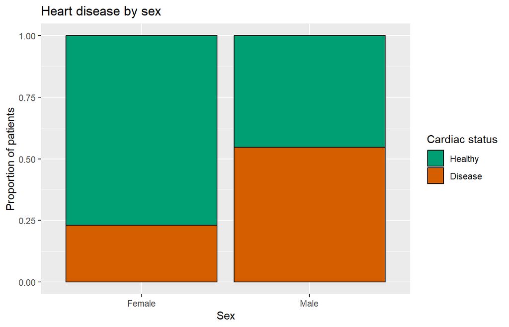

```r
# Long format for ggplot2 (geom_col plots values that are already computed)
sex_props <- as.data.frame(prop.table(sex_counts, margin = 1),
                           responseName = "proportion")

ggplot(sex_props, aes(x = Sex, y = proportion, fill = Status)) +
  geom_col(colour = "black") +
  scale_fill_manual(values = status_colours) +
  ylim(0, 1) +
  labs(title = "Heart disease by sex",
       x = "Sex", y = "Proportion of patients", fill = "Cardiac status")
```

Heart disease is present in 23.0% of women (20 of 87) and in 54.6% of men (100 of 183), so it is more than twice as frequent in men in this sample. The sample is predominantly male (183 men versus 87 women), so the estimate for women is less precise.

## 3.3 Fasting blood sugar and heart disease

```r
fbs_counts <- table(fbs = heart_data$fbs, target = heart_data$target)
fbs_counts
```

```
##    target
## fbs   0   1
##   0 127 103
##   1  23  17
```

```r
# Proportion of patients in each disease group, within each glycaemia level
round(prop.table(fbs_counts, margin = 1), 3)
```

```
##    target
## fbs     0     1
##   0 0.552 0.448
##   1 0.575 0.425
```

`fbs` is 1 when fasting blood sugar exceeds 120 mg/dl and 0 otherwise. Of the 230 patients with normal glycaemia, 103 have heart disease (44.8%); of the 40 patients with elevated glycaemia, 17 do (42.5%). The two proportions are almost identical, so elevated fasting sugar does not appear to be associated with disease in this sample. The absolute counts are higher in the normal group simply because that group is much larger.

## 3.4 Men with disease and above-average resting blood pressure

```r
mean_bps <- mean(heart_data$trestbps)
mean_bps
```

```
## [1] 131.3444
```

```r
exertional_angina <- heart_data %>%
  filter(sex == 1, trestbps > mean_bps, target == 1)

table(exertional_angina = exertional_angina$exang)
```

```
## exertional_angina
##  0  1
## 18 24
```

There are 42 men with heart disease and a resting blood pressure above the sample mean (131.3 mm Hg). Of these, 18 have no exercise-induced angina (`exang = 0`) and 24 do (`exang = 1`), which is 57.1%.

## 3.5 Precautions before deploying a diagnostic algorithm

Before implementing a diagnostic support algorithm in a real hospital, one must first verify that the training data represent the whole population that will use it, with enough patients of each sex, age and ethnicity. In our own sample, 68% of patients are men (183 of 270), and a model trained on these data could perform worse in women. Overall performance is not enough: the algorithm must be evaluated separately in every subgroup, because a good average accuracy can hide systematic errors in a minority group. It must also be validated on the hospital’s own data, since the local population can differ from the training one. The algorithm should remain a support tool rather than replace the clinician, who keeps the final decision and must be able to understand what a prediction is based on. Finally, its behaviour should be audited periodically after deployment to detect bias or performance drift, and patient data must be protected.

# Part 3. Descriptive statistics and graphics

## 4.1 Descriptive statistics of continuous variables

```r
continuous_vars <- c("age", "trestbps", "chol", "thalach")

heart_data %>%
  select(all_of(continuous_vars)) %>%
  summarise(across(everything(), list(
    mean = mean, sd = sd, median = median,
    q1 = ~ quantile(.x, 0.25), q3 = ~ quantile(.x, 0.75), iqr = IQR
  ))) %>%
  tidyr::pivot_longer(everything(),
                      names_to = c("variable", ".value"),
                      names_pattern = "(.*)_(mean|sd|median|q1|q3|iqr)") %>%
  mutate(across(where(is.numeric), ~ round(.x, 2)))
```

| variable | mean | sd | median | q1 | q3 | iqr |
| --- | --- | --- | --- | --- | --- | --- |
| age | 54.43 | 9.11 | 55.0 | 48 | 61 | 13 |
| trestbps | 131.34 | 17.86 | 130.0 | 120 | 140 | 20 |
| chol | 249.66 | 51.69 | 245.0 | 213 | 280 | 67 |
| thalach | 149.68 | 23.17 | 153.5 | 133 | 166 | 33 |

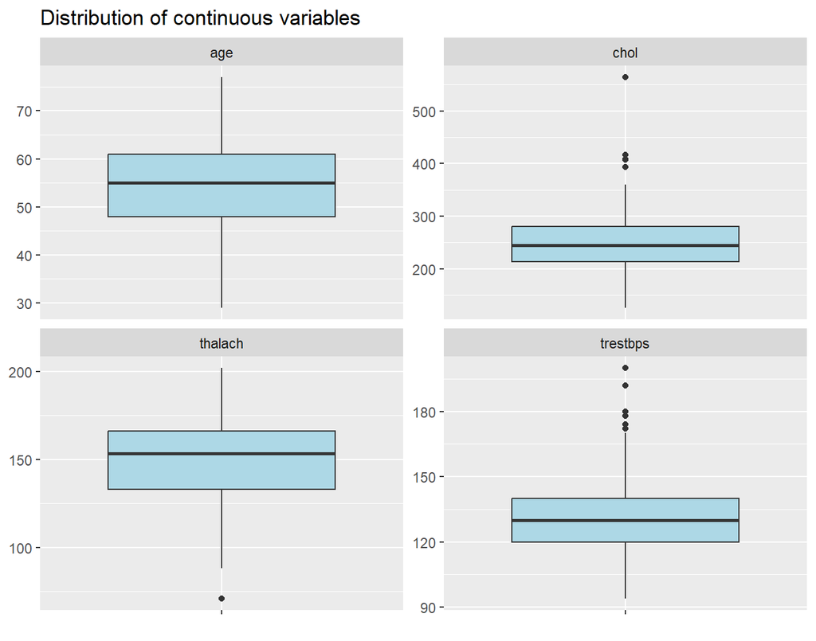

```r
heart_data %>%
  select(all_of(continuous_vars)) %>%
  tidyr::pivot_longer(everything(), names_to = "variable", values_to = "value") %>%
  ggplot(aes(x = "", y = value)) +
  geom_boxplot(fill = "lightblue") +
  facet_wrap(~ variable, scales = "free_y") +
  labs(title = "Distribution of continuous variables", x = NULL, y = NULL)
```

- **Age:** mean 54.4 years, median 55, SD 9.1. Mean and median are nearly equal and the box is symmetric, so the distribution is symmetric with no outliers.
- **Resting blood pressure:** mean 131.3 mm Hg, median 130, IQR 20. Slightly right-skewed, with several high outliers (above about 170 mm Hg) that correspond to marked hypertension.
- **Cholesterol:** mean 249.7 mg/dl, median 245, the largest relative dispersion (SD 51.7, IQR 67). It is the most right-skewed variable, with very high outliers up to 564 mg/dl.
- **Maximum heart rate:** mean 149.7 bpm, median 153.5, SD 23.2. Slightly left-skewed (mean below median) with one low outlier at 71 bpm.

## 4.2 Maximum heart rate by disease status

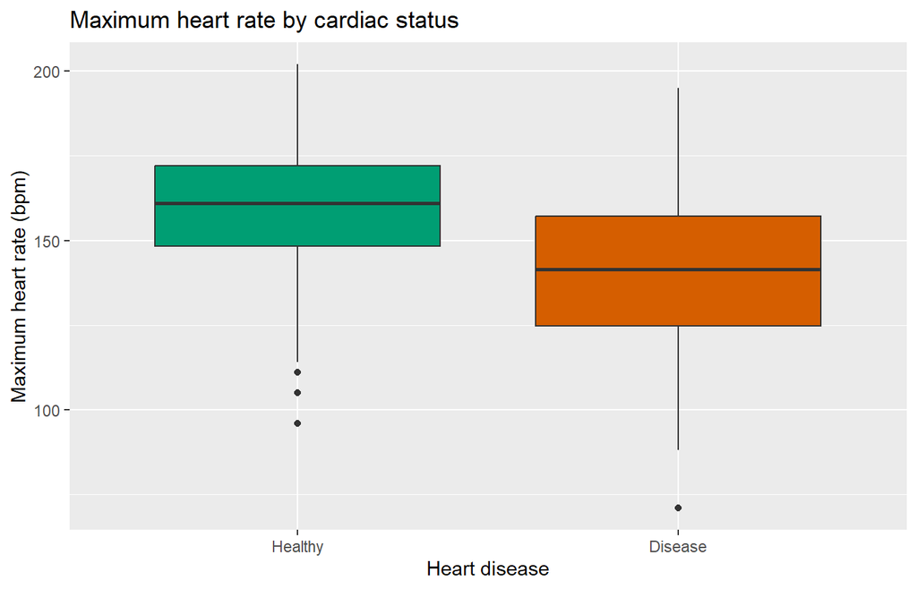

```r
ggplot(heart_data, aes(x = status_label, y = thalach, fill = status_label)) +
  geom_boxplot(show.legend = FALSE) +
  scale_fill_manual(values = status_colours) +
  labs(title = "Maximum heart rate by cardiac status",
       x = "Heart disease", y = "Maximum heart rate (bpm)")
```

```r
heart_data %>%
  group_by(status_label) %>%
  summarise(median_thalach = median(thalach))
```

| status_label | median_thalach |
| --- | --- |
| Healthy | 161.0 |
| Disease | 141.5 |

Patients with heart disease reach a lower maximum heart rate (median 141.5 bpm) than patients without disease (median 161.0 bpm), about 20 bpm less. The boxes overlap only partially and each group’s median falls outside the other’s box, so the difference is clear. This suggests that a reduced ability to raise the heart rate during exercise is associated with heart disease. It is an observed association in this sample and does not imply causation.

## 4.3 Resting ECG and heart disease

```r
ecg_counts <- table(ECG = heart_data$restecg, Disease = heart_data$target)
ecg_counts
```

```
##    Disease
## ECG  0  1
##   0 85 46
##   1  1  1
##   2 64 73
```

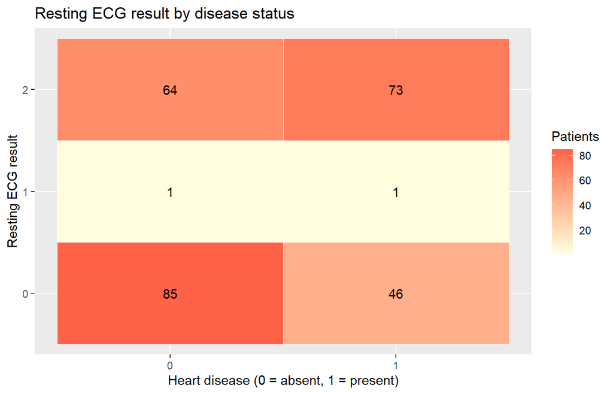

```r
ecg_df <- as.data.frame(ecg_counts)

ggplot(ecg_df, aes(x = Disease, y = ECG, fill = Freq)) +
  geom_tile(colour = "white") +
  geom_text(aes(label = Freq)) +
  scale_fill_gradient(low = "lightyellow", high = "tomato") +
  labs(title = "Resting ECG result by disease status",
       x = "Heart disease (0 = absent, 1 = present)",
       y = "Resting ECG result", fill = "Patients")
```

The most frequent pattern is a normal resting ECG (0) in patients without disease (85 patients). Among patients with disease, the most common result is probable left ventricular hypertrophy (2), with 73 patients. In proportion, disease is more frequent in patients with ECG type 2 (73 of 137, 53%) than in those with a normal ECG (46 of 131, 35%), suggesting an association between resting ECG abnormalities and disease. Type 1 has only 2 patients and cannot be interpreted.

## 4.4 Cholesterol distribution in patients with disease

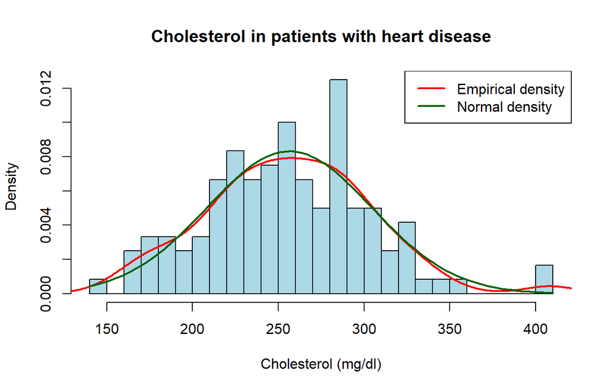

```r
disease_chol <- heart_data %>%
  filter(target == 1) %>%
  pull(chol)

# Histogram on a density scale with empirical and theoretical normal curves
hist(disease_chol,
     freq = FALSE, breaks = 20, col = "lightblue", border = "black",
     xlab = "Cholesterol (mg/dl)", ylab = "Density",
     main = "Cholesterol in patients with heart disease")
lines(density(disease_chol), col = "red", lwd = 2)
curve(dnorm(x, mean = mean(disease_chol), sd = sd(disease_chol)),
      add = TRUE, col = "darkgreen", lwd = 2)
legend("topright", legend = c("Empirical density", "Normal density"),
       col = c("red", "darkgreen"), lwd = 2)
```

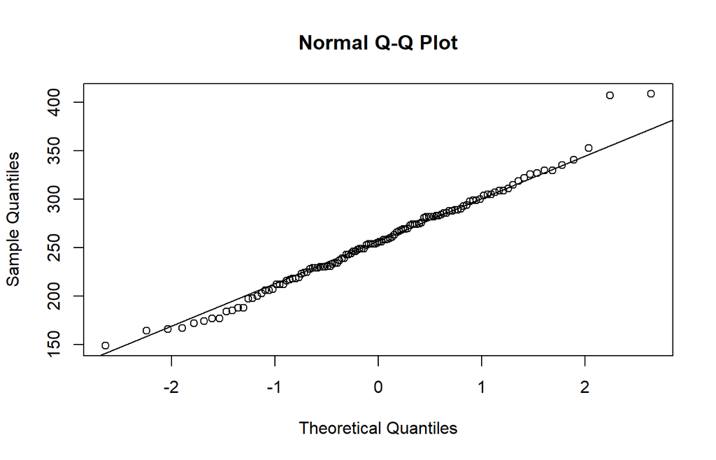

```r
# Q-Q plot and Shapiro-Wilk test (H0: the data are normally distributed)
qqnorm(disease_chol)
qqline(disease_chol)
```

```r
shapiro.test(disease_chol)
```

```
##
##  Shapiro-Wilk normality test
##
## data:  disease_chol
## W = 0.98607, p-value = 0.2558
```

The histogram with the empirical (red) and theoretical normal (green) density curves shows a reasonable fit, with a slight right skew caused by a few high cholesterol values. In the Q-Q plot the points follow the reference line, with small deviations in the tails (two values above 400 mg/dl). The Shapiro-Wilk test (W = 0.986, p = 0.256) does not reject normality, because the p-value is above 0.05. Cholesterol in patients with heart disease can therefore be considered approximately normal.

## 4.5 Correlation matrix

```r
numeric_vars <- heart_data %>%
  select(age, trestbps, chol, thalach, oldpeak)

correlation_matrix <- cor(numeric_vars)
round(correlation_matrix, 2)
```

```
##            age trestbps  chol thalach oldpeak
## age       1.00     0.27  0.22   -0.40    0.19
## trestbps  0.27     1.00  0.17   -0.04    0.22
## chol      0.22     0.17  1.00   -0.02    0.03
## thalach  -0.40    -0.04 -0.02    1.00   -0.35
## oldpeak   0.19     0.22  0.03   -0.35    1.00
```

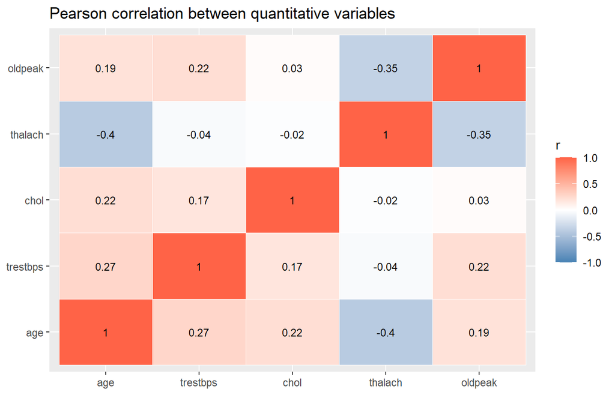

```r
correlation_df <- as.data.frame(as.table(correlation_matrix))

ggplot(correlation_df, aes(x = Var1, y = Var2, fill = Freq)) +
  geom_tile(colour = "white") +
  geom_text(aes(label = round(Freq, 2)), size = 3) +
  scale_fill_gradient2(low = "steelblue", mid = "white", high = "tomato",
                       midpoint = 0, limits = c(-1, 1)) +
  labs(title = "Pearson correlation between quantitative variables",
       x = NULL, y = NULL, fill = "r")
```

Only the five truly quantitative variables are included (`age`, `trestbps`, `chol`, `thalach`, `oldpeak`); the rest are categories encoded as numbers, for which a Pearson correlation is meaningless. The strongest correlation is the negative one between age and maximum heart rate (r = -0.40): older patients reach a lower maximum heart rate during the stress test, which is expected because the heart’s capacity to accelerate declines with age. It is followed by `thalach` and `oldpeak` (r = -0.35), meaning that patients with greater exercise-induced ST depression tend to reach a lower maximum heart rate. The remaining correlations are weak, so these variables are fairly independent of each other. Correlation measures only linear association and does not imply causation.